# simon-5502-12-demo

## File details

This program was written by Steve Simon on 2025-04-29 and is placed in the public domain. You can use this program any way you please.

- Data used in this program
  - Will the baby walk away?
    - Your baby is learning to walk. The baby begins by holding onto a couch. Whenever she is next to the couch, there is a 25 percent chance that she will take a step forward and a 75 percent chance that she will stay clutching the couch. If the baby is one or more steps away from the couch, there’s a 25 percent chance that she will take a step forward, a 25 percent chance she’ll stay in place and a 50 percent chance she’ll take one step back toward the couch. In the long run, what percent of the time does the baby choose to clutch the couch?
  - ECMO study
    - ECMO babies: 28 out of 29 survived
    - Control babies: 6 out of 10 survived

```r
library(brms)
library(tidyverse)

R.version.string
```

```
[1] "R version 4.5.0 (2025-04-11 ucrt)"
```

```r
Sys.Date()
```

```
[1] "2025-04-29"
```

## Baby walk data

```r
n <- 10000
couch_distance <- rep(NA, n)
couch_distance[1] <- 0
random_uniforms <- runif(n-1)
for (i in 2:n) {
    if (couch_distance[i-1]==0) {
        if (random_uniforms[i-1] < 0.75) step=0
        if (random_uniforms[i-1] >= 0.75) step=1
    }
    if (couch_distance[i-1] > 0) {
        if (random_uniforms[i-1] < 0.5) step=-1
        if (random_uniforms[i-1] >= 0.5 & random_uniforms[i-1] < 0.75) step=0
        if (random_uniforms[i-1] >= 0.75) step=1
    }
    couch_distance[i] <- couch_distance[i-1] + step
}

couch_distance
```

[output not shown]

[output cut: 402 more lines]

## Baby walk graph

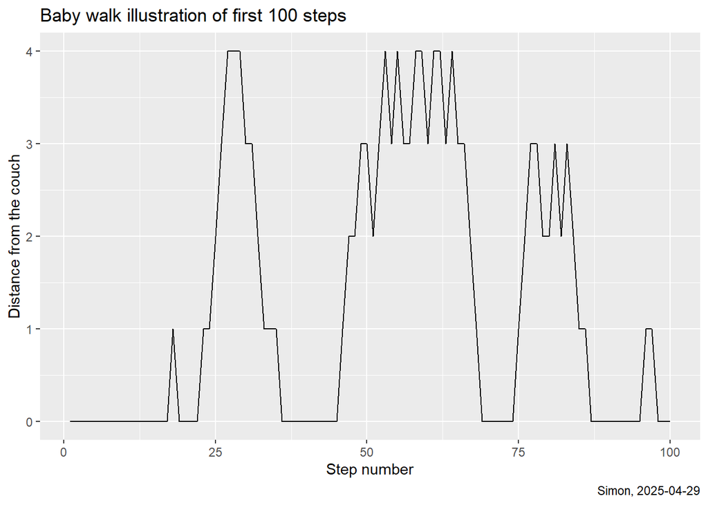

```r
tibble(t=1:100, d=couch_distance[1:100]) |>
    ggplot() +
    aes(x=t, y=d) +
    geom_line() +
        labs(
        title="Baby walk illustration of first 100 steps",
        x="Step number",
        y="Distance from the couch",
        caption="Simon, 2025-04-29")
```

## Baby walk histogram

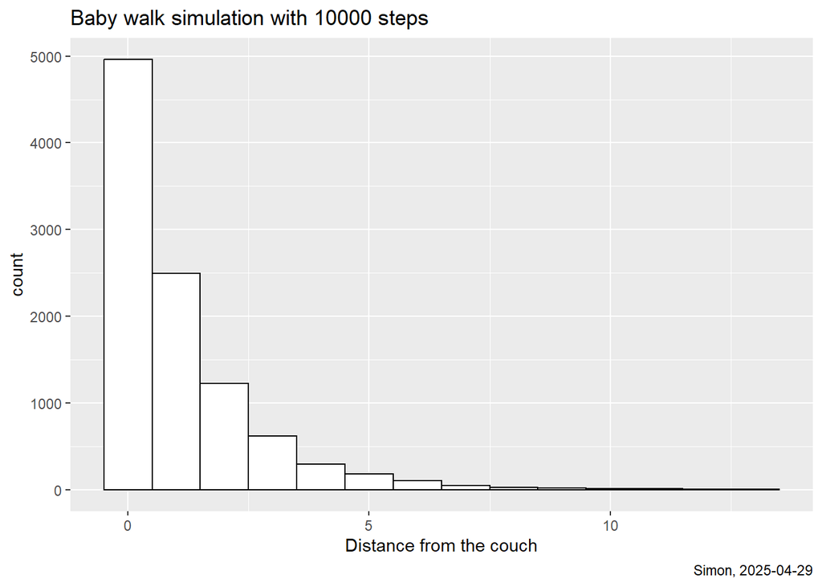

```r
tibble(d=couch_distance) |>
    ggplot() +
    aes(x=d) +
    geom_histogram(
        color="black",
        fill="white",
        binwidth=1) +
    labs(
        title="Baby walk simulation with 10000 steps",
        x="Distance from the couch",
        caption="Simon, 2025-04-29")
```

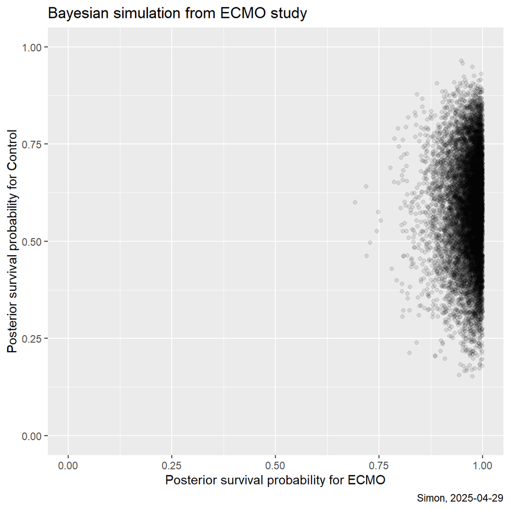

```r
n <- 10000
ecmo <- rbeta(n, 29, 1)
control <- rbeta(n, 7, 5)

tibble(ecmo, control) |>
    ggplot() +
    aes(x=ecmo, y=control) +
    geom_point(alpha=0.1) +
    expand_limits(x=0:1, y=0:1) +
    labs(
        title="Bayesian simulation from ECMO study",
        x="Posterior survival probability for ECMO",
        y="Posterior survival probability for Control",
        caption="Simon, 2025-04-29")
```